# Grad School Survey

Roger Tu

September 3, 2019

## Import and initialize the graduate student survey data.

Index graduate student dataframe columns.

Create a vector containing all indices to be removed.

## Create the subsetted dataframe by removing all indices in dimensions from to_Remove

Fixed an index because someone wrote “24 I think” for a parameter that should have been numeric (This guy changed everything to a factor!!)

## Created a theme for plotting.

x-axis text horizontally adjusted by +0.5. Axis is black. White background, border, major and minor lines.

## Age of Graduate Students

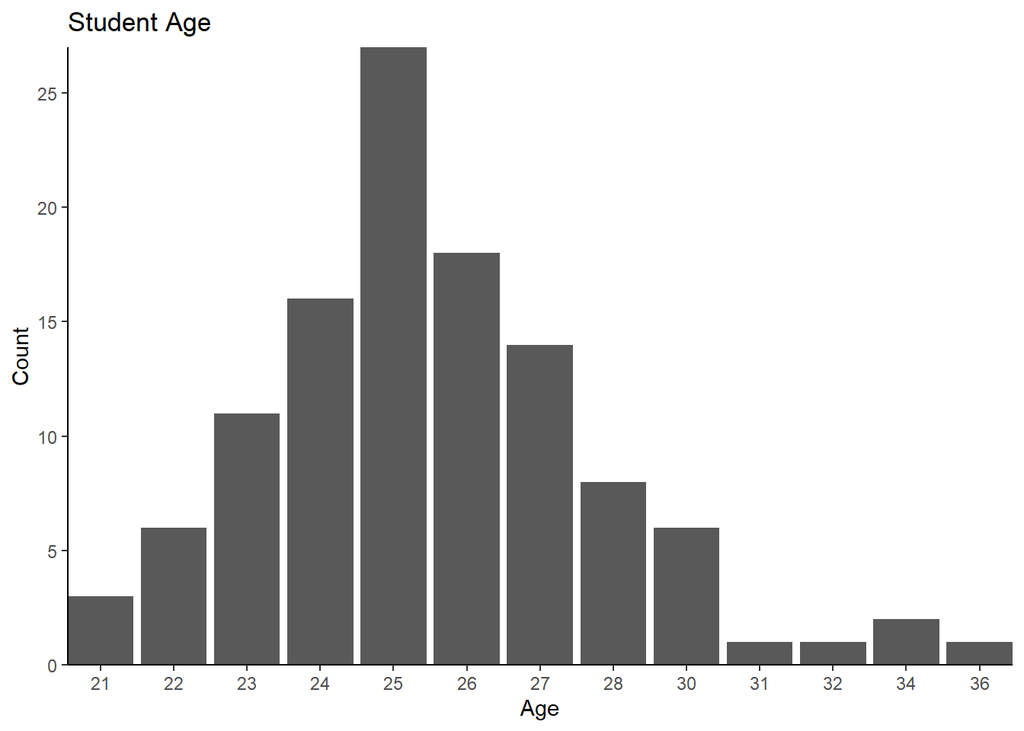

## Of those who answered the survey: Age of Graduate Students by Year in Graduate School

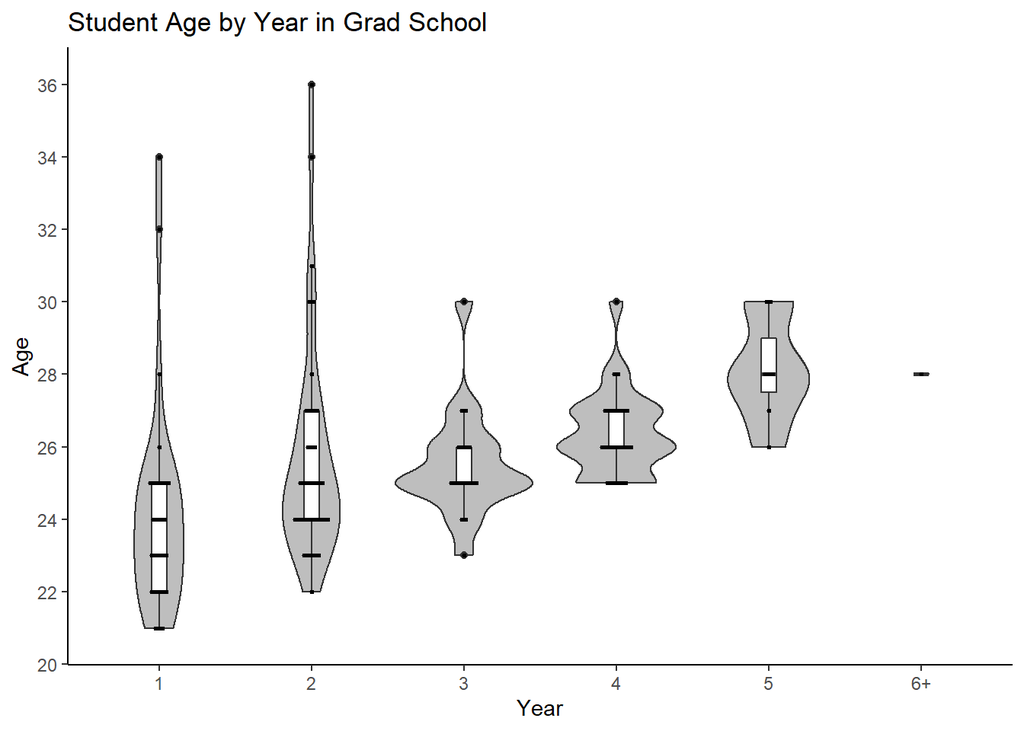

## Graduate Student Survey Response by Year

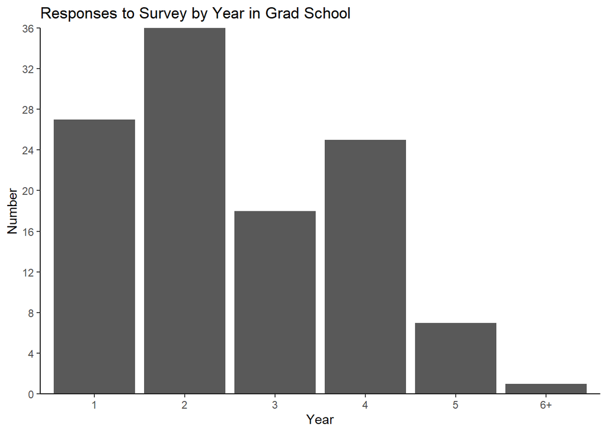

## Graduate Student Survey Response by Gender

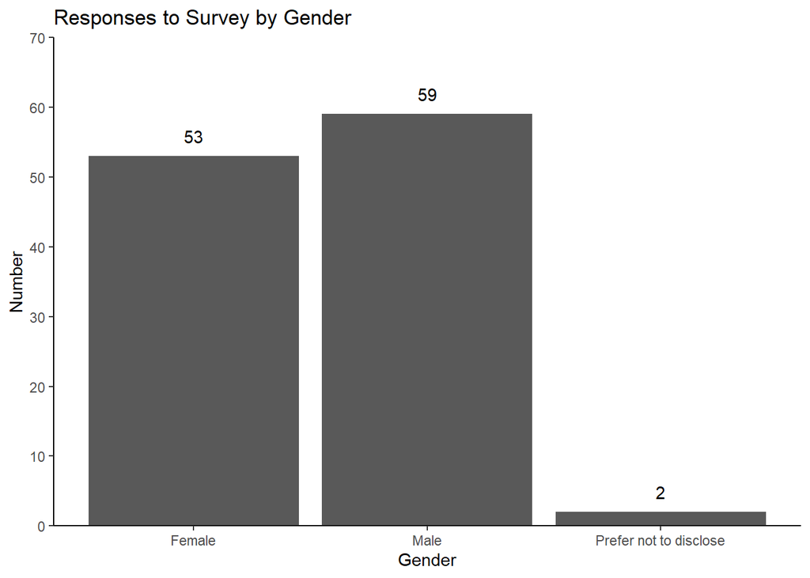

## Graduate Student Survey Response by Gender and Year

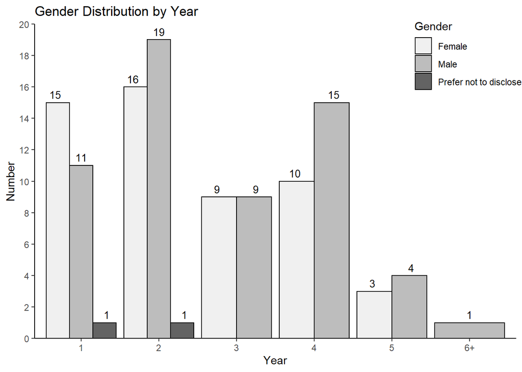

## Response by Department

Most people only listed one department. Some listed Molecular Medicine + “xyz Department”. For those who had more than one, they were categorized as Molecular Medicine

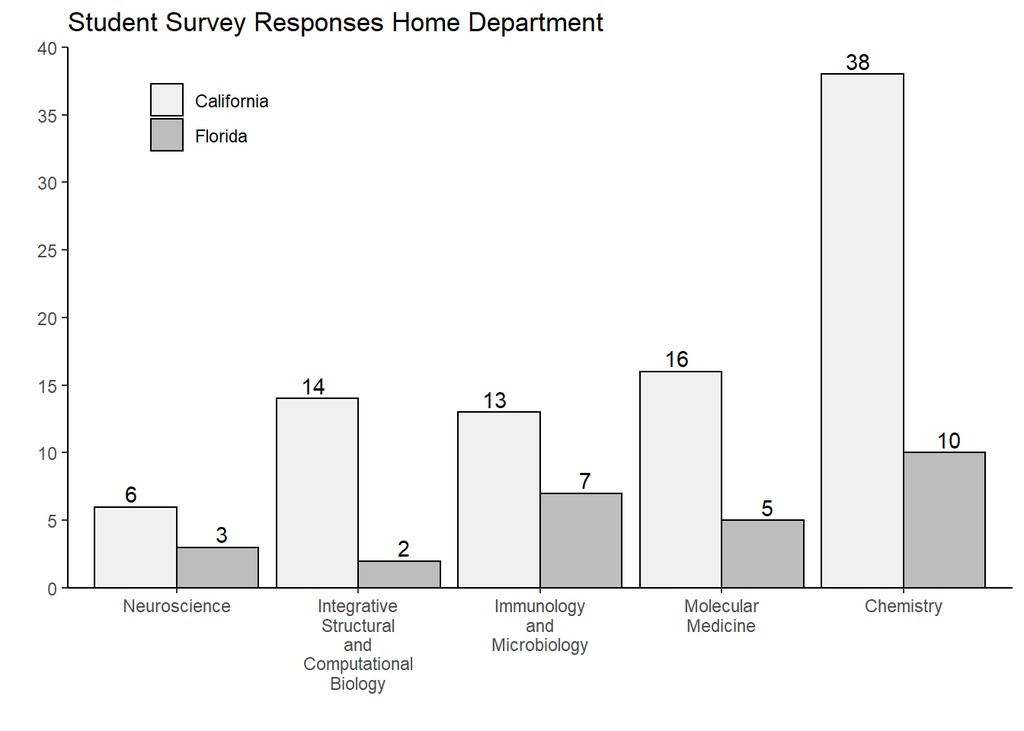

## Response by Home Department and Lab Size

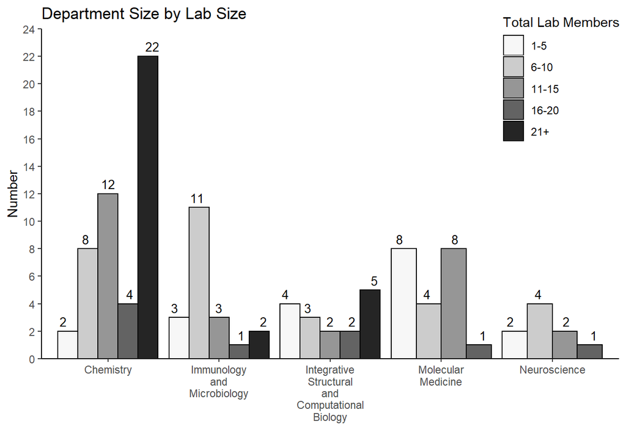

## Response by Lab Size

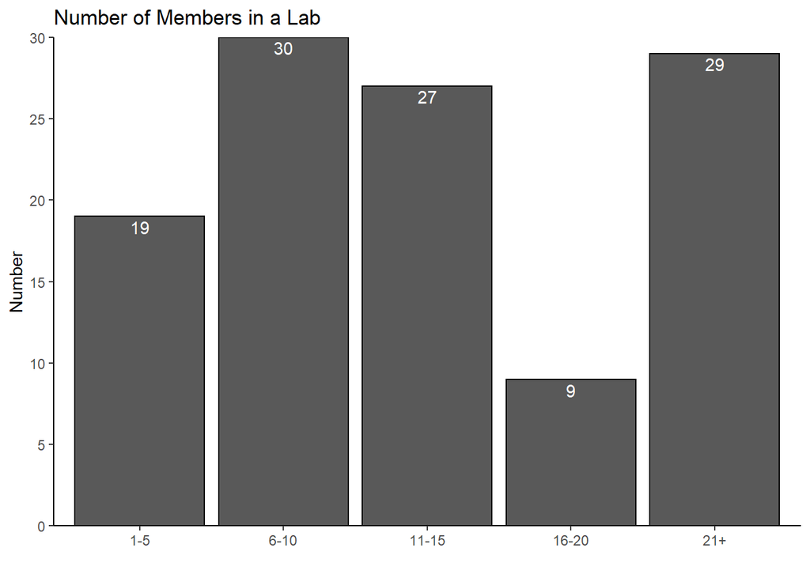

## Grad Students in Labs by Campus

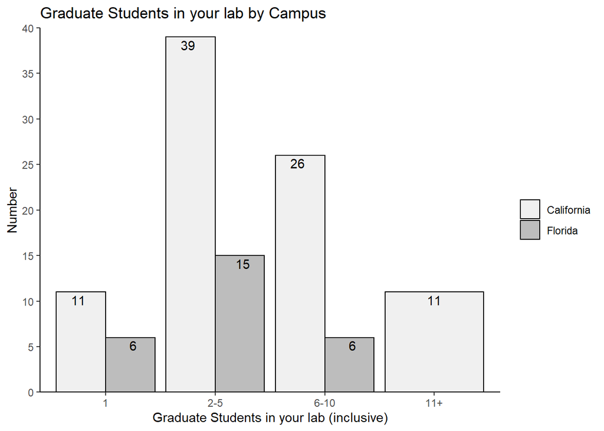

## Campus

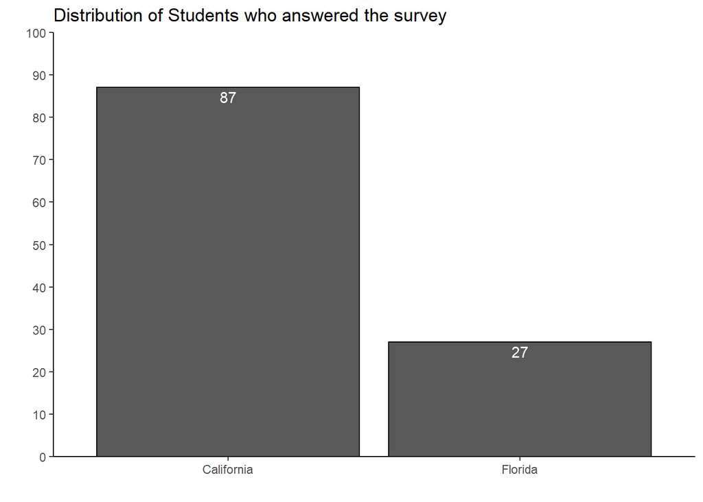

## Where to put the lounge

Had to Subset the data first and fill in the blanks.

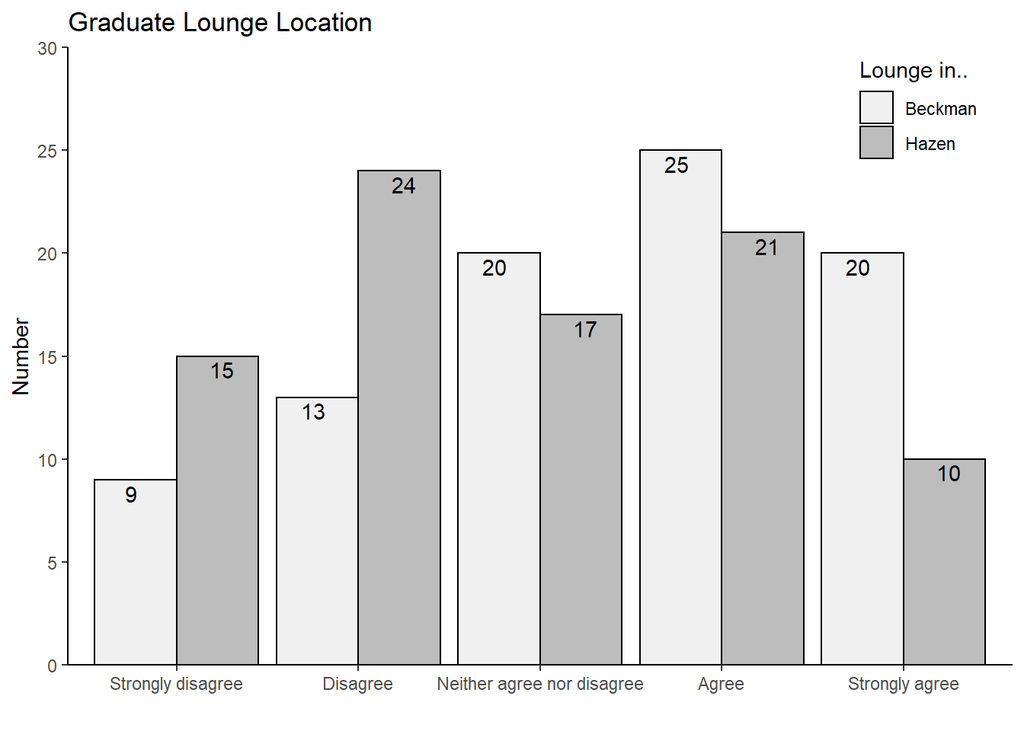

## What was your experience prior to Scripps?

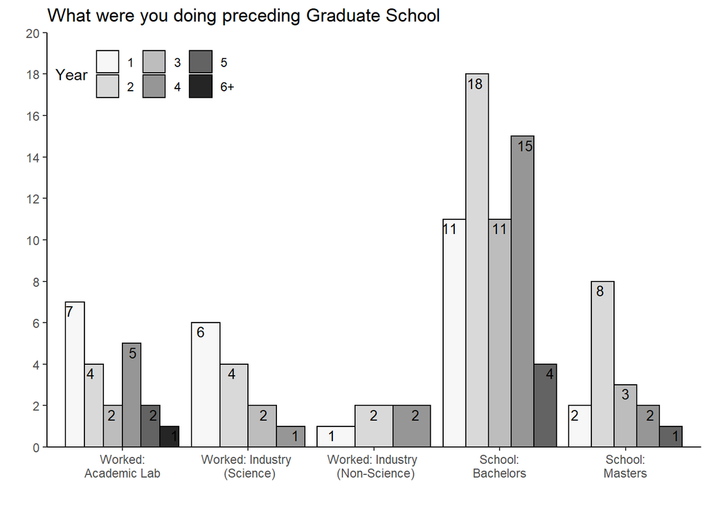

## Prentation, Publications and On-Campus Interviews

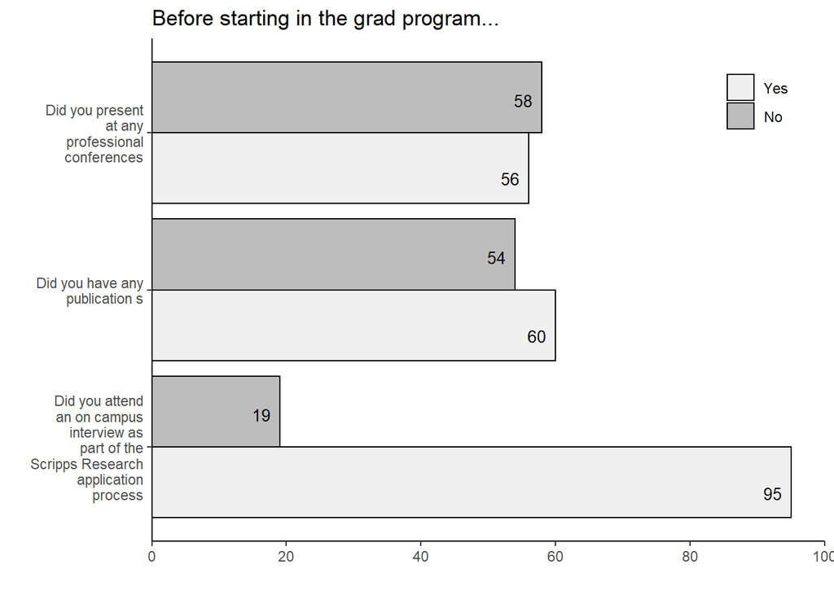

## Grad lounge recommendation

I’m gong to try and do a word cloud. Here I’m transforming the data to remove weird funky stuff

Text cleaning

Transformation of data to a matrix then to dataframe. Create a vector (docs2) and complete the stemmed words.

Build Word Cloud with stemmed words as input word, and frequency.

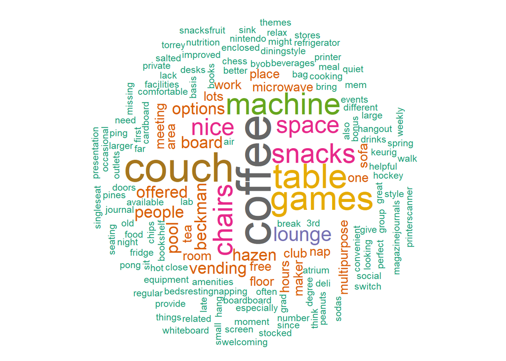

## Influences on Enrollment.

Clean up the data… If entry has more than one, Changed entry to that lower level. Lots of clean up here.

## How factors contributed to decsion in choosing Scripps:

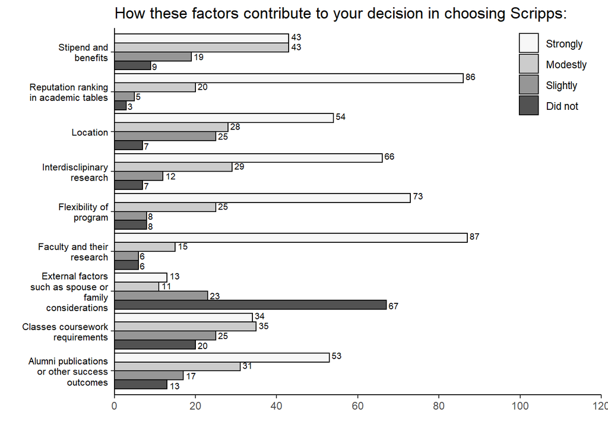

## Graduate Schools Applied to and Accepted into. Some person got accepted to Zero Schools

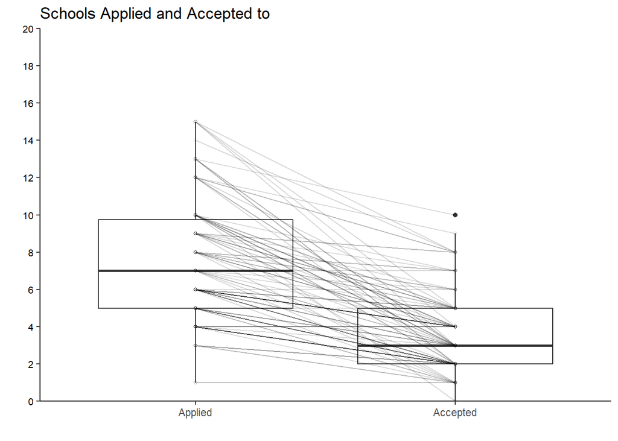

### Faceted by Year

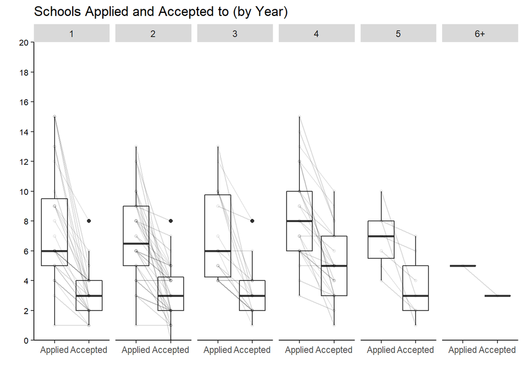

```r
aa + facet_grid(. ~ Year) + labs(title = "Schools Applied and Accepted to (by Year)")
```

## Before enrolling into grad school, I had the … required to succeed (faceted by Year)

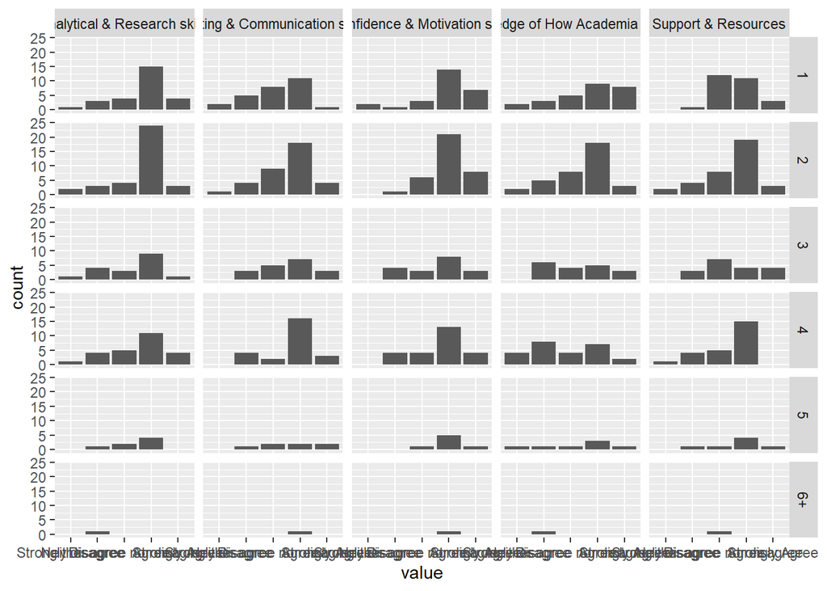

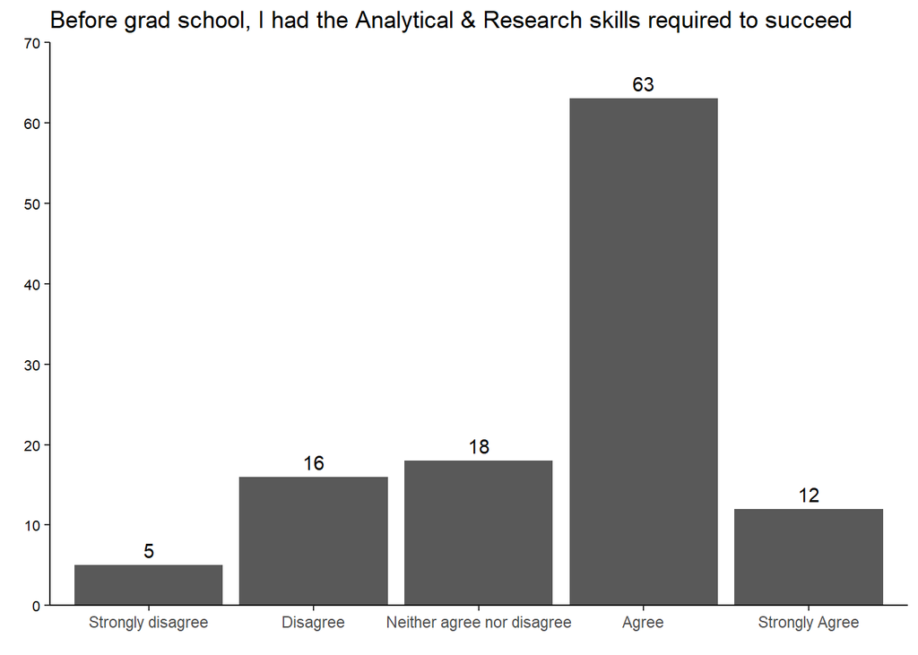

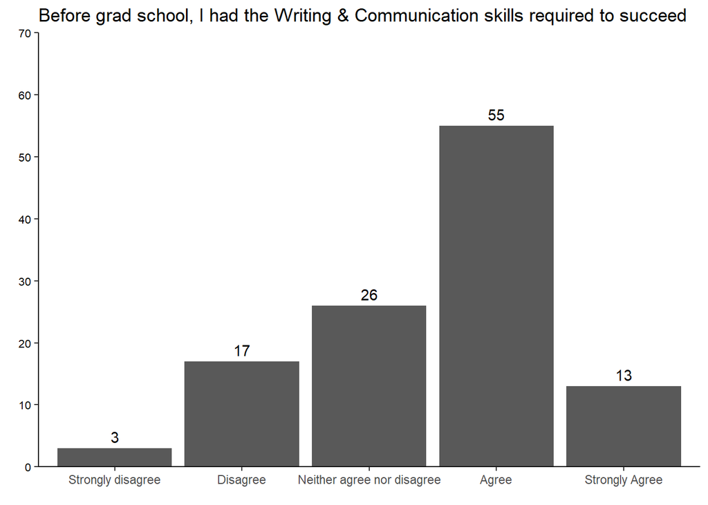

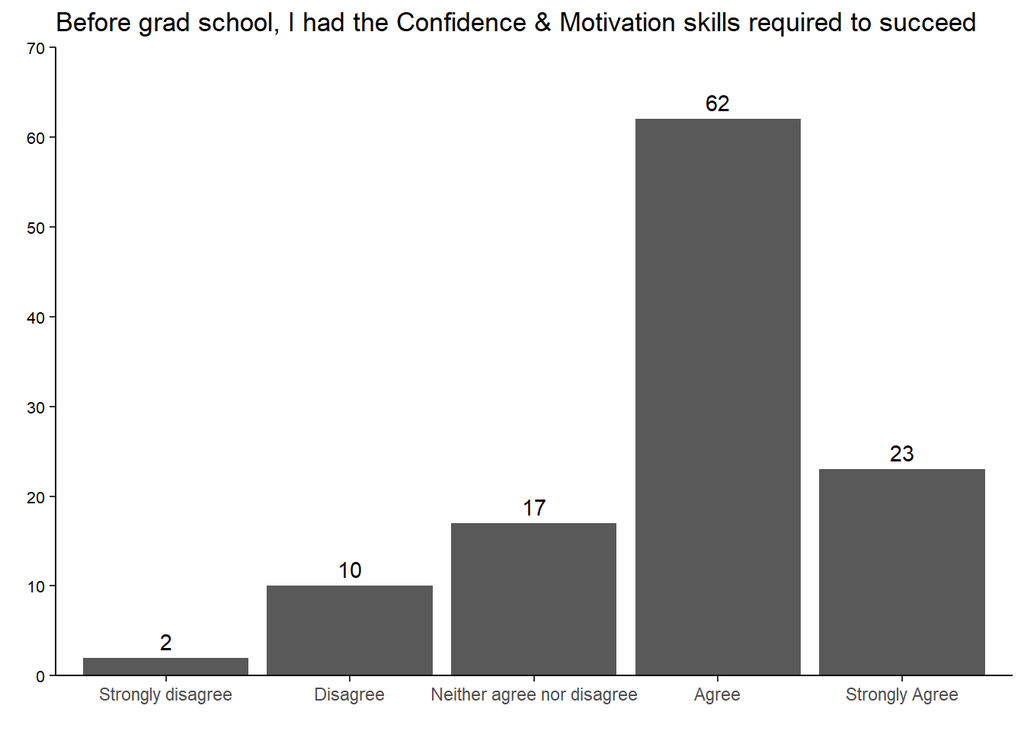

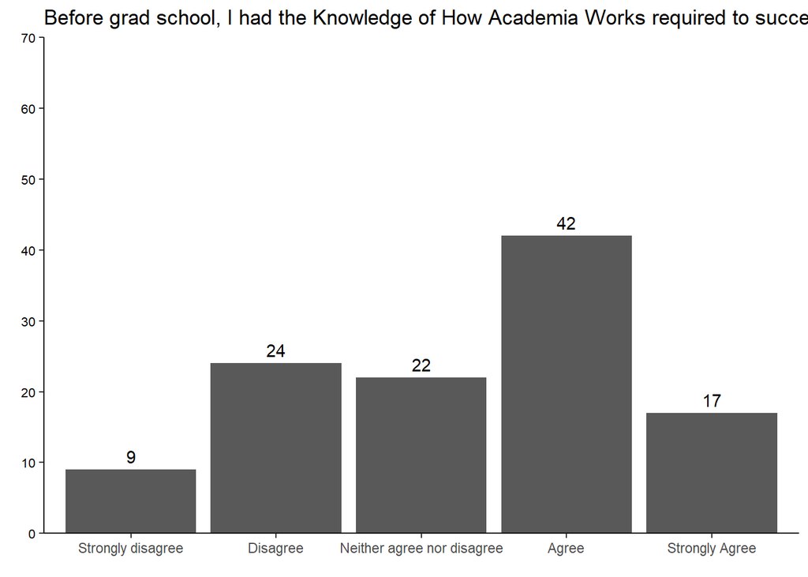

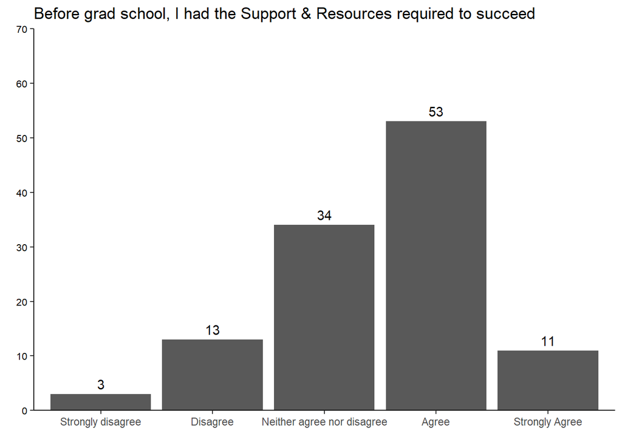

## Grad Student Retreat

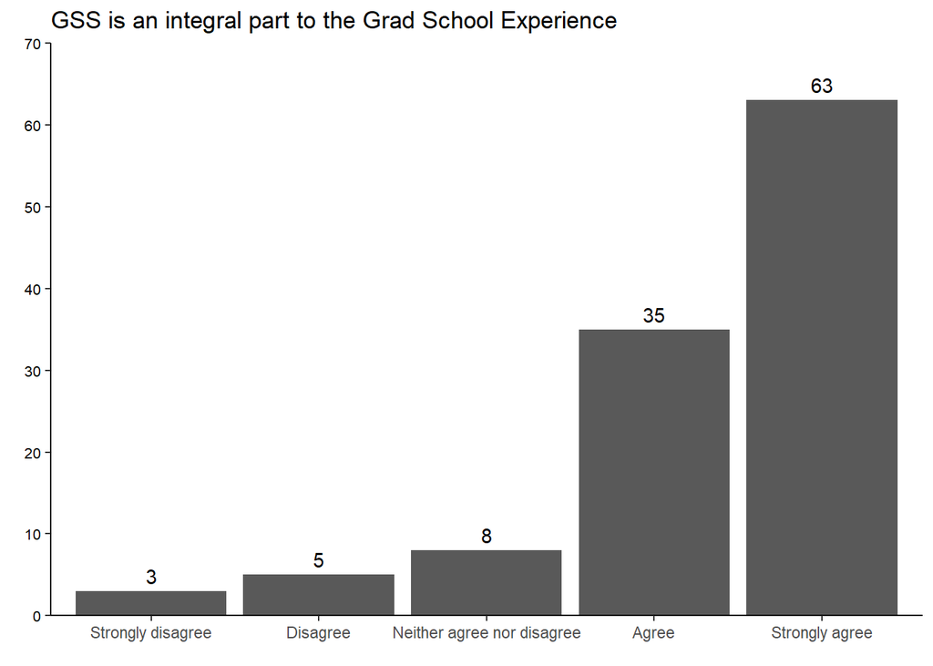

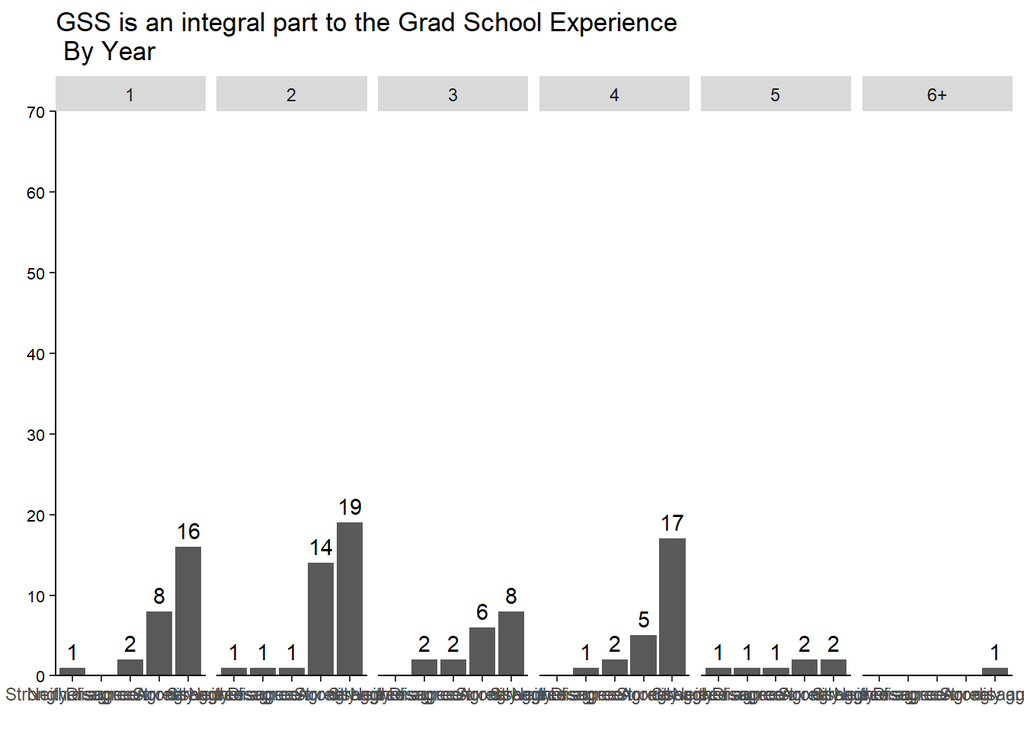

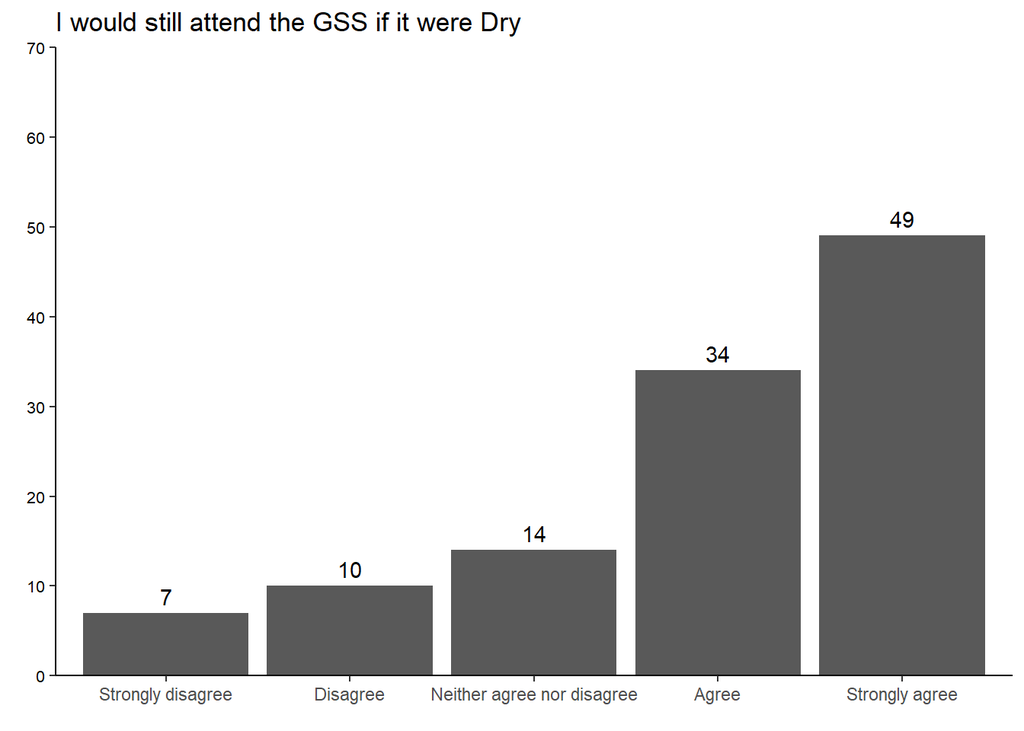

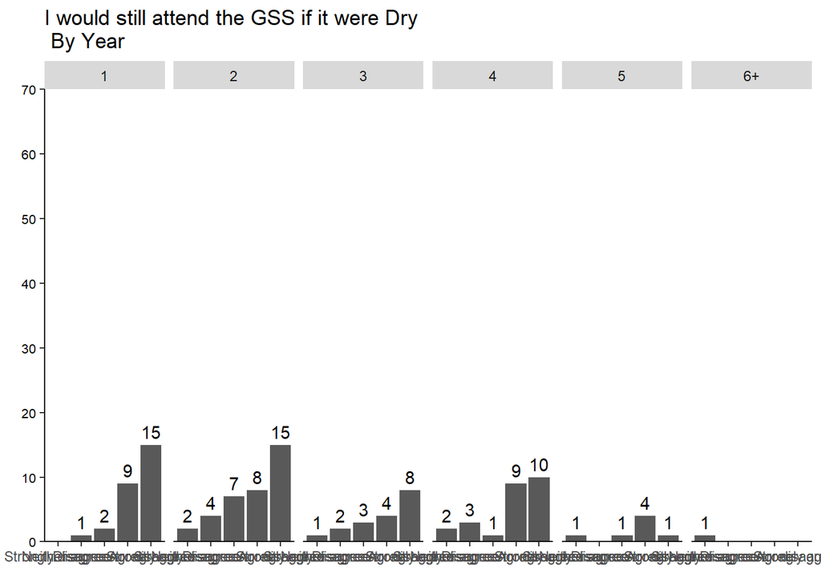

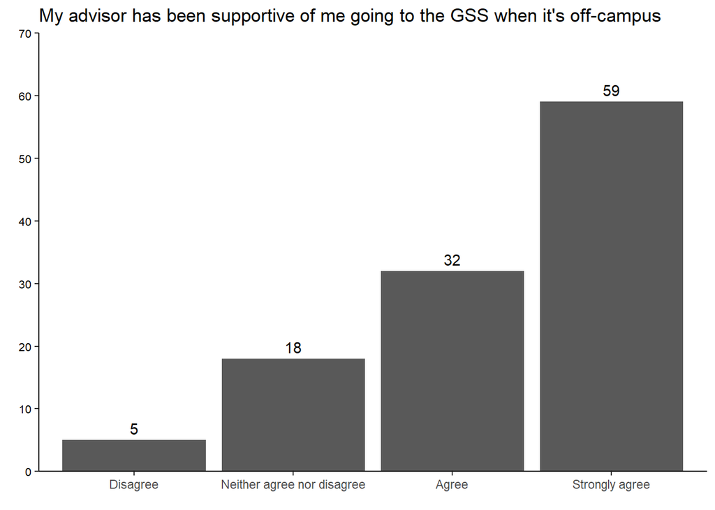

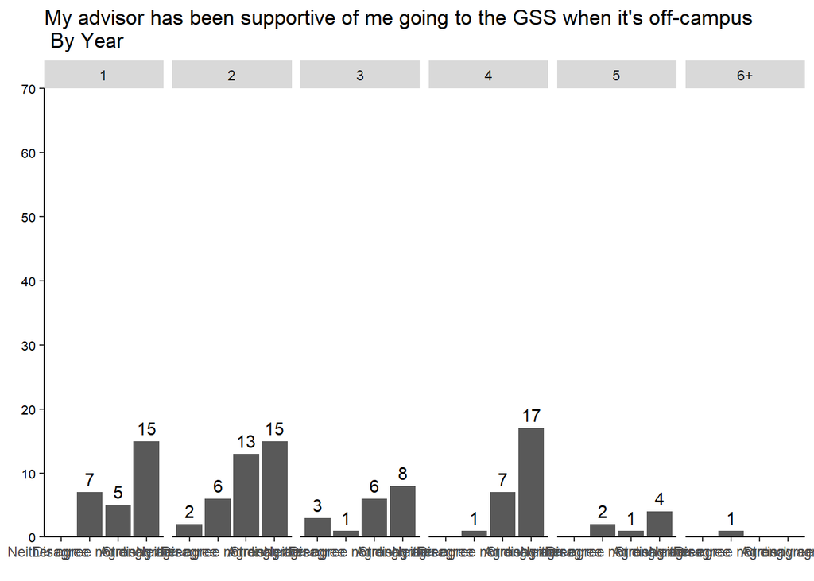

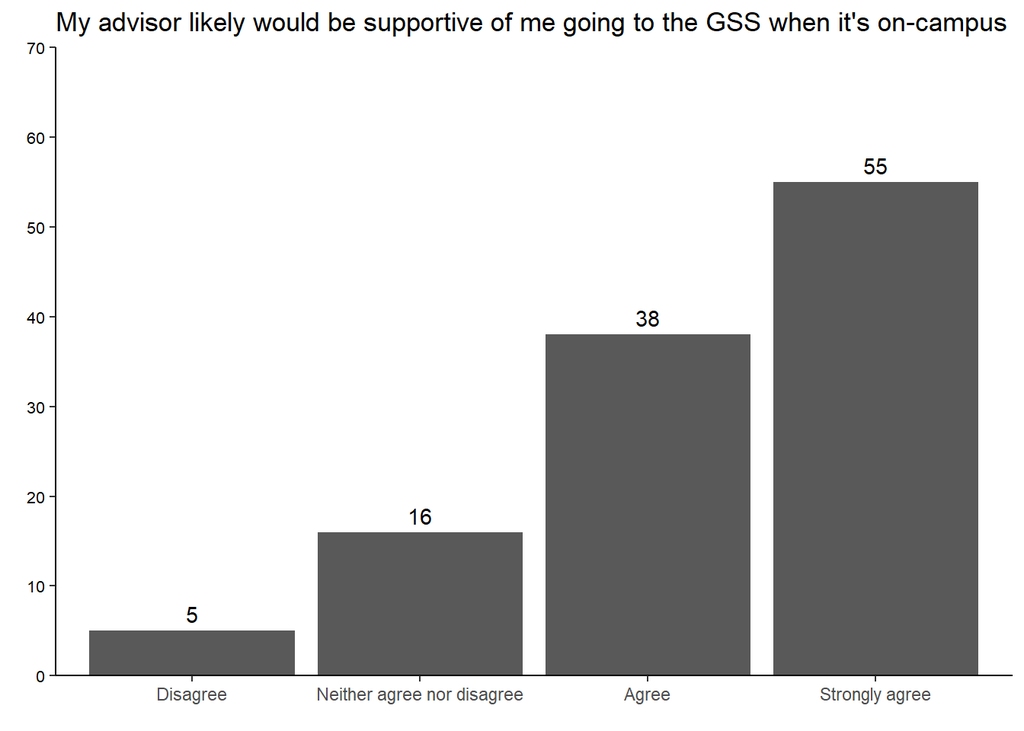

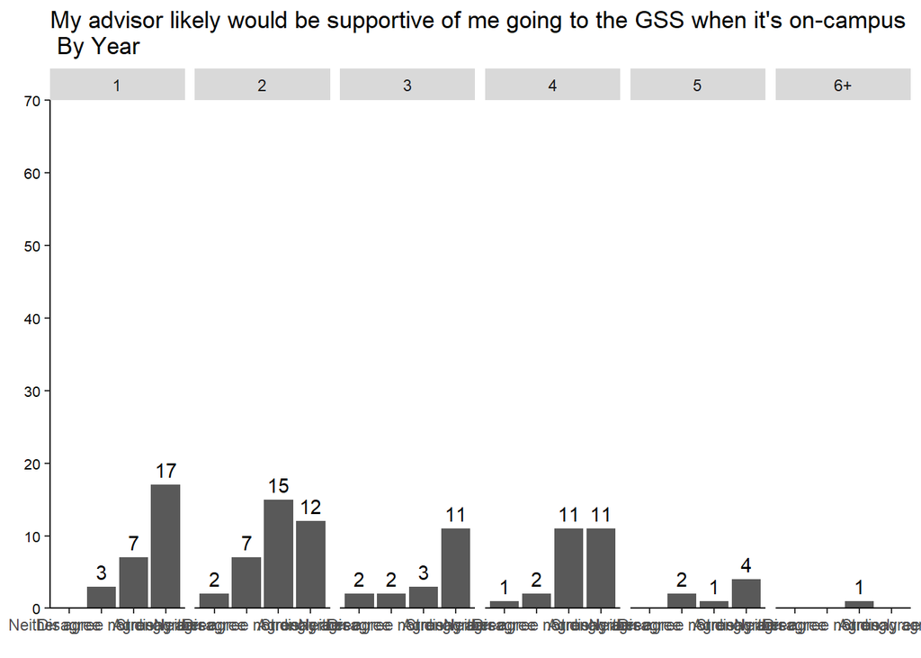